# Bike Rentals(Bay Area) Trends (Year- 2019)

## Investigation Overview

In this investigation, We will explore the trends of bike rentals and predict the high bike rental seasons. The main focus will be the bike rental times, which can be split into time of day, week and month. We will further explore by the user types i.e., by Customer or Subscriber.

## Dataset Overview

The data consists of 2506983 records of bike rental data. The dataset includes the rental details such as the duration of rental, start and end station details, bike id's and the user details. The rental_access_method is ignored because this was introduced mid year.

#### Bike Rental by Month

Distribution of bike rentals by month for the year 2019. The highest month of rentals being July and lowest being December.

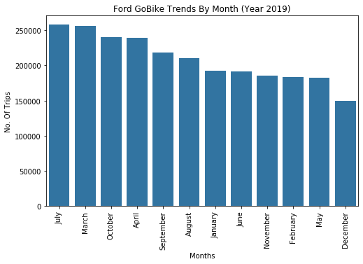

```python
plt.figure(figsize=(8,5))

base_color = sb.color_palette()[0]
m_order = trip_details.startmonth.value_counts().index
g = sb.countplot(data = trip_details, x = 'startmonth', color = base_color, order = m_order)

g.axes.set_xlabel('Months')
g.axes.set_ylabel('No. Of Trips')
g.set_title('Ford GoBike Trends By Month (Year 2019)')
g.set_xticklabels(g.get_xticklabels(), rotation=90);
```

#### Bike Rental by Week

Distribution of bike rentals by week for the year 2019. The maximum rentals being on weekdays and the lowest being on weekends.

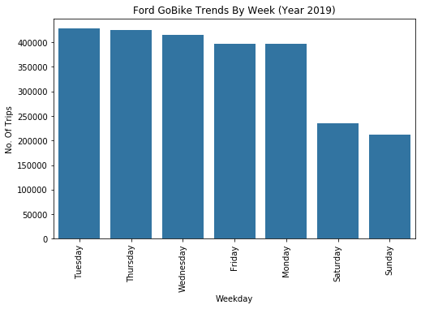

```python
plt.figure(figsize=(8,5))
base_color = sb.color_palette()[0]
w_order = trip_details.startweek.value_counts().index

g = sb.countplot(data = trip_details, x = 'startweek', color = base_color, order = w_order)
g.axes.set_xlabel('Weekday')
g.axes.set_ylabel('No. Of Trips')
g.set_title('Ford GoBike Trends By Week (Year 2019)')
g.set_xticklabels(g.get_xticklabels(), rotation=90);
```

#### Bike Rental by Time of day

Distribution of bike rentals by time of day for the year 2019. The maximum rentals are in the Evenings.

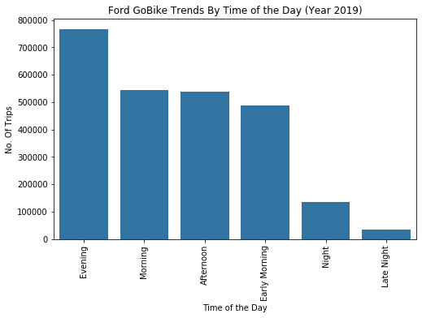

```python
plt.figure(figsize=(8,5))
base_color = sb.color_palette()[0]
t_order = trip_details.timeofday.value_counts().index
g = sb.countplot(data = trip_details, x = 'timeofday', color = base_color, order = t_order)

g.axes.set_xlabel('Time of the Day')
g.axes.set_ylabel('No. Of Trips')
g.set_title('Ford GoBike Trends By Time of the Day (Year 2019)')
g.set_xticklabels(g.get_xticklabels(), rotation=90);
```

#### Bike Rental by month for each user type (Customer vs Subscriber)

The bike rental trends here are plotted for both the user types. December was the lowest for all the bike rentals, Whereas when plotting the trends for each user type, we can see the maximum bike rentals for Customers being December. The maximum bike rentals for a Subscriber is in the month of March and July being the second most.

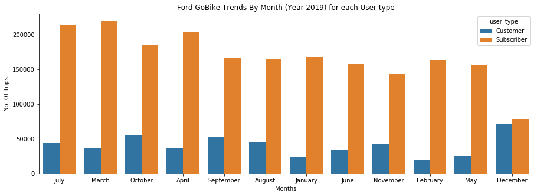

```python
plt.figure(figsize=(15,5))

base_color = sb.color_palette()[0]
m_order = trip_details.startmonth.value_counts().index
g = sb.countplot(data = trip_details, x = 'startmonth', hue = 'user_type', order=m_order)
g.axes.set_xlabel('Months')
g.axes.set_ylabel('No. Of Trips')
g.set_title('Ford GoBike Trends By Month (Year 2019) for each User type');
```

#### Bike Rental by week for each user type(Customer vs Subscriber)

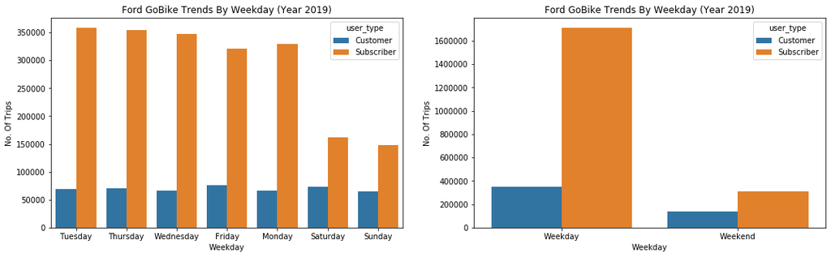

```python
plt.figure(figsize=(18,5))

plt.subplot(1, 2, 1)
base_color = sb.color_palette()[0]
w_order = trip_details.startweek.value_counts().index
g = sb.countplot(data = trip_details, x = 'startweek', hue = 'user_type', order=w_order)
g.axes.set_xlabel('Weekday')
g.axes.set_ylabel('No. Of Trips')
g.set_title('Ford GoBike Trends By Weekday (Year 2019)')

plt.subplot(1, 2, 2)
day_type = trip_details.start_time.dt.weekday.apply(lambda x: 'Weekday' if x < 5 else 'Weekend')
base_color = sb.color_palette()[0]
g = sb.countplot(data = trip_details, x = day_type, hue = 'user_type')
g.axes.set_xlabel('Weekday')
g.axes.set_ylabel('No. Of Trips')
g.set_title('Ford GoBike Trends By Weekday (Year 2019)');
```

#### Bike Rental by time of day for each user type(Customer vs Subscriber)

The popular time of bike rentals for Customers are on the Evenings and Afternoons whereas for Subscribers it is in the Evenings and Mornings.

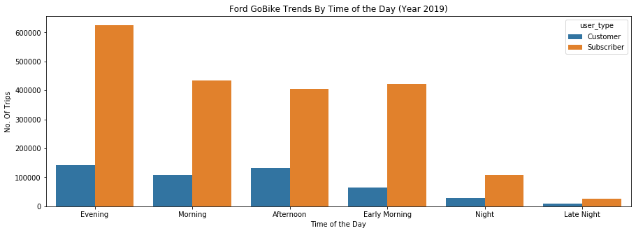

```python
plt.figure(figsize=(15,5))
base_color = sb.color_palette()[0]
t_order = trip_details.timeofday.value_counts().index

g = sb.countplot(data = trip_details, x = 'timeofday', hue = 'user_type', order=t_order)
g.axes.set_xlabel('Time of the Day')
g.axes.set_ylabel('No. Of Trips')
g.set_title('Ford GoBike Trends By Time of the Day (Year 2019)');
```

#### Bike rental by time of day and week for each user type

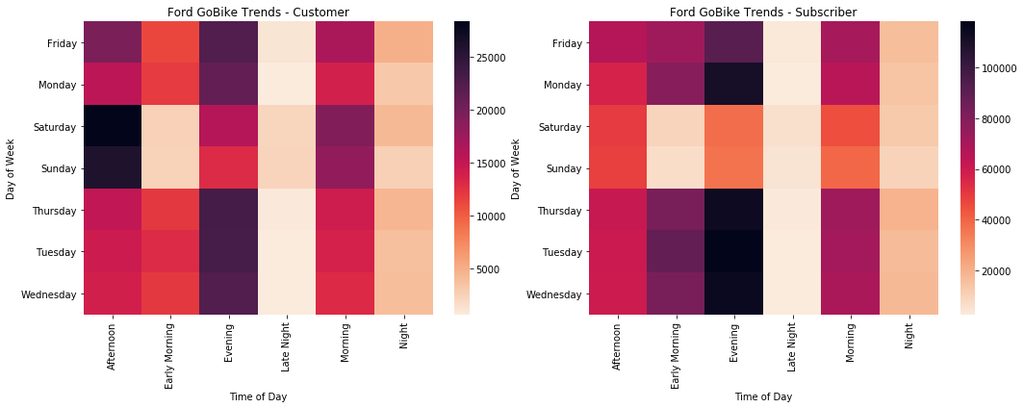

```python
plt.figure(figsize=[15, 6])

plt.subplot(1, 2, 1)
ct_counts = trip_details[trip_details['user_type'] == 'Customer'].groupby(['startweek', 'timeofday']).size()
ct_counts = ct_counts.reset_index(name='count')
ct_counts = ct_counts.pivot(index='startweek', columns='timeofday', values='count')
sb.heatmap(ct_counts, cmap='rocket_r')
plt.title('Ford GoBike Trends - Customer', loc='center')
plt.xlabel('Time of Day')
plt.ylabel('Day of Week')
plt.xticks(rotation=90)
plt.yticks(rotation=0)
plt.tight_layout()

plt.subplot(1, 2, 2)
ct_counts = trip_details[trip_details['user_type'] == 'Subscriber'].groupby(['startweek', 'timeofday']).size()
ct_counts = ct_counts.reset_index(name='count')
ct_counts = ct_counts.pivot(index='startweek', columns='timeofday', values='count')
sb.heatmap(ct_counts, cmap='rocket_r')
plt.title('Ford GoBike Trends - Subscriber', loc='center')
plt.xlabel('Time of Day')
plt.ylabel('Day of Week')
plt.xticks(rotation=90)
plt.tight_layout();
```

#### Bike rental by time of day and month for each user type

We can observe the popular time of bike rentals for Customers in the month of December(Afternoon, Evening and Morning) and September and October(In the evenings). Similarly the popular time of bike rentals for Subscribers are in the months of March, April and July in the Evenings. Also, the Subscribers have a high frequency of bike rentals throughout the year in the evenings.

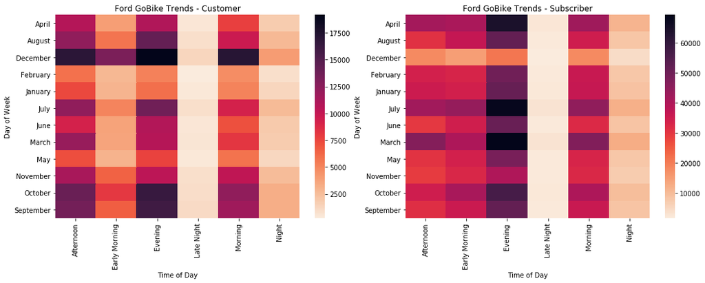

```python
plt.figure(figsize=[15, 6])

plt.subplot(1, 2, 1)
ct_counts = trip_details[trip_details['user_type'] == 'Customer'].groupby(['startmonth', 'timeofday']).size()
ct_counts = ct_counts.reset_index(name='count')
ct_counts = ct_counts.pivot(index='startmonth', columns='timeofday', values='count')
sb.heatmap(ct_counts, cmap='rocket_r')
plt.title('Ford GoBike Trends - Customer', loc='center')
plt.xlabel('Time of Day')
plt.ylabel('Day of Week')
plt.xticks(rotation=90)
plt.yticks(rotation=0)
plt.tight_layout()

plt.subplot(1, 2, 2)
ct_counts = trip_details[trip_details['user_type'] == 'Subscriber'].groupby(['startmonth', 'timeofday']).size()
ct_counts = ct_counts.reset_index(name='count')
ct_counts = ct_counts.pivot(index='startmonth', columns='timeofday', values='count')
sb.heatmap(ct_counts, cmap='rocket_r')
plt.title('Ford GoBike Trends - Subscriber', loc='center')
plt.xlabel('Time of Day')
plt.ylabel('Day of Week')
plt.xticks(rotation=90)
plt.tight_layout();
```